# p8105_hw5_xf2226

Xin Fang

11/20/2021

# Problem 1

The code chunk below imports and cleans the data

```r
homicides_df =
  read_csv("./data/homicide-data.csv", na = c("", "Unknown")) %>%
  mutate(
    city_state = str_c(city, state),
    resolution = case_when(
      disposition == "Closed without arrest" ~ "unsolved",
      disposition == "Open/No arrest" ~ "unsolved",
      disposition == "Closed by arrest" ~ "solved")
    ) %>%
  relocate(city_state) %>%
  filter(city_state != "TulsaAL")
```

Let’s focus on Baltimore MD

```r
baltimore_df =
  homicides_df %>%
  filter(city_state == "BaltimoreMD")

baltimore_summary = baltimore_df %>%
  summarize(
    unsolved = sum(resolution == "unsolved"),
    n = n()
  )

baltimore_test =
  prop.test(x = baltimore_summary %>% pull(unsolved),
          n = baltimore_summary %>% pull(n))

baltimore_test %>%
  broom::tidy()
```

```
## # A tibble: 1 × 8
##   estimate statistic  p.value parameter conf.low conf.high method    alternative
##      <dbl>     <dbl>    <dbl>     <int>    <dbl>     <dbl> <chr>     <chr>
## 1    0.646      239. 6.46e-54         1    0.628     0.663 1-sample… two.sided
```

Let’s try to iterate across cities

First, write a function

```r
prop_test_function = function(city_df) {
  city_summary =
    city_df %>%
    summarize(
      unsolved = sum(resolution == "unsolved"),
      n = n()
    )

  city_test =
    prop.test(x = city_summary %>% pull(unsolved),
            n = city_summary %>% pull(n))

  return(city_test)
}

prop_test_function(baltimore_df)
```

```
##
##  1-sample proportions test with continuity correction
##
## data:  city_summary %>% pull(unsolved) out of city_summary %>% pull(n), null probability 0.5
## X-squared = 239, df = 1, p-value <2e-16
## alternative hypothesis: true p is not equal to 0.5
## 95 percent confidence interval:
##  0.628 0.663
## sample estimates:
##     p
## 0.646
```

Let’s map the function

```r
results_df =
  homicides_df %>%
  nest(data = uid:resolution) %>%
  mutate(
    test_results = map(data, prop_test_function),
    tidy_results = map(test_results, broom::tidy)
  ) %>%
  select(city_state, tidy_results) %>%
  unnest(tidy_results) %>%
  select(city_state, estimate, starts_with("conf"))
```

Try to make a plot showing estimates and confidence intervals

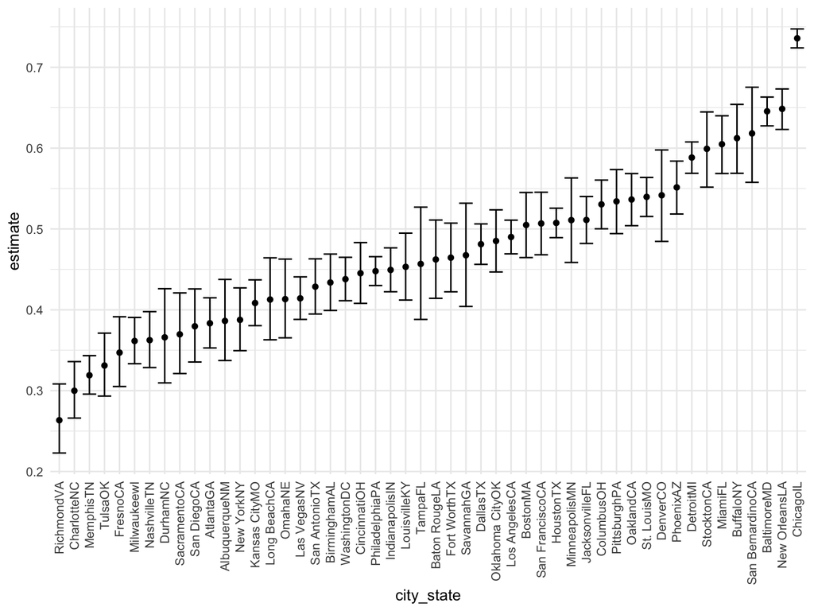

```r
results_df %>%
  mutate(city_state = fct_reorder(city_state, estimate)) %>%
  ggplot(aes(x = city_state, y = estimate)) +
  geom_point() +
  geom_errorbar(aes(ymin = conf.low, ymax = conf.high)) +
  theme(axis.text.x = element_text(angle = 90, vjust = 0.5, hjust = 1))
```

```r
homicides_df %>%
  group_by(city_state) %>%
  summarize(
    unsolved = sum(resolution == "unsolved"),
    n = n()
  ) %>%
  mutate(
    test_results = map2(unsolved, n, prop.test),
    tidy_results = map(test_results, broom::tidy)
  ) %>%
  select(city_state, tidy_results) %>%
  unnest(tidy_results) %>%
  select(city_state, estimate, starts_with("conf"))
```

```
## # A tibble: 50 × 4
##    city_state    estimate conf.low conf.high
##    <chr>            <dbl>    <dbl>     <dbl>
##  1 AlbuquerqueNM    0.386    0.337     0.438
##  2 AtlantaGA        0.383    0.353     0.415
##  3 BaltimoreMD      0.646    0.628     0.663
##  4 Baton RougeLA    0.462    0.414     0.511
##  5 BirminghamAL     0.434    0.399     0.469
##  6 BostonMA         0.505    0.465     0.545
##  7 BuffaloNY        0.612    0.569     0.654
##  8 CharlotteNC      0.300    0.266     0.336
##  9 ChicagoIL        0.736    0.724     0.747
## 10 CincinnatiOH     0.445    0.408     0.483
## # … with 40 more rows
```

# Problem 2

Load the control and experimental data set

```r
research_data = tibble(
  files = list.files("./data/case-control/"),
  data = map(str_c("./data/case-control/",files), read_csv)
)
```

Tidy the result; manipulate file names to include control arm and subject ID, make sure weekly observations are “tidy”, and do any other tidying that’s necessary

```r
research_cleaned =
  research_data %>%
  unnest(data) %>%
  mutate(research_arm = ifelse(str_detect(files, "con"), "Control Arm", "Experimental Arm")) %>%
  mutate(subject_id = (substr(files, 5, 6))) %>%
  select(subject_id, research_arm, starts_with("week")) %>%
  pivot_longer(
    week_1:week_8,
    names_to = "week",
    names_prefix = "week_",
    values_to = "data"
  )
```

A spaghetti plot showing observations on each subject over time, and comment on differences between groups.

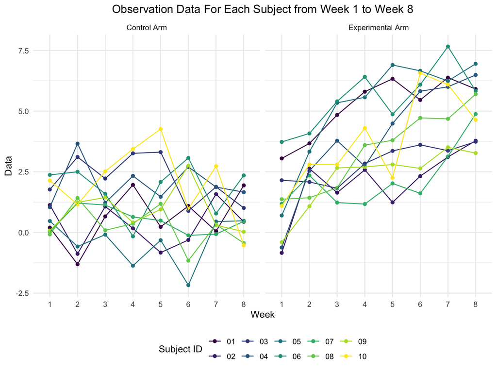

```r
research_cleaned %>%
  ggplot(aes(x = week, y = data, group = subject_id, color = subject_id)) +
  geom_point() +
  geom_line() +
  facet_grid(. ~ research_arm) +
  theme(legend.position = "bottom", plot.title = element_text(hjust = 0.5)) +
  labs(
    title = "Observation Data For Each Subject from Week 1 to Week 8",
    x = "Week",
    y = "Data",
    color = "Subject ID"
  )
```

From the above spaghetti plot we can see that, for subjects in the control arm, their observation data remained roughly unchanged (with a very slight overall decrease) over the 8-week study period. The majority of the collected data ranged from ~-1.75 to ~3.75. For subjects in the experimental arm, we see an overall increasing trend of observation data, which means, overall, subjects in the experimental arm are getting higher observation data from week 1 to week 8. At week 8, subjects in the experimental arm have much higher data (3~7) than subjects the in the control arm (-1~2.5). The actual interpretation of this will depend on the study context.

# Problem 3

Importing the Data

```r
set.seed(10)

iris_with_missing = iris %>%
  map_df(~replace(.x, sample(1:150, 20), NA)) %>%
  mutate(Species = as.character(Species))
```

Write a Function

```r
fill_in_missing = function(x) {
  if (is.numeric(x)) {
    ifelse(is.na(x) == T, mean(x, na.rm = T), x)
  }
  else if (is.character(x))　{
    ifelse(is.na(x) == T, "virginica", x)
  }
  else if (!is.numeric(x) & !is.character(x)) {
     x == "Warning: Argument x neither numeric nor character"
  }
}
```

Using the Function to fill in missing values in the iris data set

```r
iris_without_missing = map_df(iris_with_missing, fill_in_missing)
```